# Working with Text and Text Analytics in R

SMUREU Data Science Bootcamp

# Working with Text and Text Analytics in R

So far in this bootcamp we have worked with:

- numbers
- tables
- maps
- geographic data

But a huge amount of real-world data is actually text.

Reviews, news articles, social media posts, interview transcripts, emails, books, and surveys are all forms of text data.

Today we will explore:

- cleaning text
- counting words and phrases
- extracting patterns from language
- identifying important words in documents
- some limitations of text analysis

```r
library(tidyverse)
library(tidytext)
```

# Apartment Reviews: Text as Data

Let’s start with a small dataset of apartment reviews.

Unlike numerical data, text is:

- messy
- inconsistent
- emotional
- ambiguous

But we can still analyze it computationally.

```r
reviews <- tibble(
  Apartment = c(
    "Mustang Station",
    "Campus View",
    "Highland House",
    "Mockingbird Flats",
    "Hilltop Lofts",
    "University Crossing",
    "Maple Terrace",
    "Lakeside Apartments"
  ),
  Stars = c(2, 4, 1, 5, 3, 2, 4, 1),
  Review = c(
    "The location is honestly great if you need to get to campus quickly, but the walls are paper thin and people are constantly yelling outside at like 2am.",
    "Pretty solid place overall. Cheap rent, decent kitchen, and I can walk to class in about 10 minutes. Maintenance is slow sometimes though.",
    "I would absolutely not live here again. My AC broke twice during August and management stopped answering emails after the first week.",
    "Loved living here. The staff remembered my name, the study rooms were actually useful, and the coffee shop downstairs became my second home.",
    "The apartment itself is nice enough and I like the gym, but parking is frustrating and guest parking is basically impossible on weekends.",
    "Moved in because it looked nice on the tour but the wifi cuts out constantly and my roommate found mold behind the bathroom cabinet midway through the semester.",
    "Honestly surprised by how much I liked this place. Quiet, clean, good lighting, and my dog was weirdly happier here than our last apartment.",
    "One night the fire alarm went off three times between midnight and 4am and nobody from management explained what happened. Also saw two cockroaches in the kitchen."
  )
)

reviews
```

| Apartment | Stars | Review |
| --- | --- | --- |
| Mustang Station | 2 | The location is honestly great if you need to get to campus quickly, but the walls are paper thin and people are constantly yelling outside at like 2am. |
| Campus View | 4 | Pretty solid place overall. Cheap rent, decent kitchen, and I can walk to class in about 10 minutes. Maintenance is slow sometimes though. |
| Highland House | 1 | I would absolutely not live here again. My AC broke twice during August and management stopped answering emails after the first week. |
| Mockingbird Flats | 5 | Loved living here. The staff remembered my name, the study rooms were actually useful, and the coffee shop downstairs became my second home. |
| Hilltop Lofts | 3 | The apartment itself is nice enough and I like the gym, but parking is frustrating and guest parking is basically impossible on weekends. |
| University Crossing | 2 | Moved in because it looked nice on the tour but the wifi cuts out constantly and my roommate found mold behind the bathroom cabinet midway through the semester. |
| Maple Terrace | 4 | Honestly surprised by how much I liked this place. Quiet, clean, good lighting, and my dog was weirdly happier here than our last apartment. |
| Lakeside Apartments | 1 | One night the fire alarm went off three times between midnight and 4am and nobody from management explained what happened. Also saw two cockroaches in the kitchen. |

# Word Counts

One of the simplest things we can measure is document length.

```r
reviews <- reviews |>
  mutate(
    word_count = str_count(Review, "\\S+"),
    char_count = str_length(Review)
  )

reviews |>
  select(Apartment, word_count, char_count)
```

| Apartment | word_count | char_count |
| --- | --- | --- |
| Mustang Station | 28 | 152 |
| Campus View | 23 | 138 |
| Highland House | 22 | 133 |
| Mockingbird Flats | 23 | 140 |
| Hilltop Lofts | 23 | 137 |
| University Crossing | 28 | 160 |
| Maple Terrace | 24 | 140 |
| Lakeside Apartments | 27 | 163 |

```r
reviews |>
  arrange(desc(word_count))
```

| Apartment | Stars | Review | word_count | char_count |
| --- | --- | --- | --- | --- |
| Mustang Station | 2 | The location is honestly great if you need to get to campus quickly, but the walls are paper thin and people are constantly yelling outside at like 2am. | 28 | 152 |
| University Crossing | 2 | Moved in because it looked nice on the tour but the wifi cuts out constantly and my roommate found mold behind the bathroom cabinet midway through the semester. | 28 | 160 |
| Lakeside Apartments | 1 | One night the fire alarm went off three times between midnight and 4am and nobody from management explained what happened. Also saw two cockroaches in the kitchen. | 27 | 163 |
| Maple Terrace | 4 | Honestly surprised by how much I liked this place. Quiet, clean, good lighting, and my dog was weirdly happier here than our last apartment. | 24 | 140 |
| Campus View | 4 | Pretty solid place overall. Cheap rent, decent kitchen, and I can walk to class in about 10 minutes. Maintenance is slow sometimes though. | 23 | 138 |
| Mockingbird Flats | 5 | Loved living here. The staff remembered my name, the study rooms were actually useful, and the coffee shop downstairs became my second home. | 23 | 140 |
| Hilltop Lofts | 3 | The apartment itself is nice enough and I like the gym, but parking is frustrating and guest parking is basically impossible on weekends. | 23 | 137 |
| Highland House | 1 | I would absolutely not live here again. My AC broke twice during August and management stopped answering emails after the first week. | 22 | 133 |

# Most Common Words

Now let’s split the reviews into individual words.

This process is often called tokenization.

```r
review_words <- reviews |>
  unnest_tokens(word, Review)

review_words |>
  count(word, sort = TRUE) |>
  head(15)
```

| word | n |
| --- | --- |
| the | 14 |
| and | 10 |
| is | 5 |
| my | 5 |
| i | 4 |
| but | 3 |
| here | 3 |
| in | 3 |
| to | 3 |
| apartment | 2 |

[output cut: 5 more lines]

Some of these words are useful.

Some are extremely common and do not tell us very much.

# Stopwords

Stopwords are very common words like:

- the
- and
- is
- of

These words are often removed because they carry little meaning by themselves.

```r
data("stop_words")

clean_review_words <- review_words |>
  anti_join(stop_words, by = "word")

clean_review_words |>
  count(word, sort = TRUE) |>
  head(15)
```

| word | n |
| --- | --- |
| apartment | 2 |
| constantly | 2 |
| honestly | 2 |
| kitchen | 2 |
| management | 2 |
| nice | 2 |
| parking | 2 |
| 10 | 1 |
| 2am | 1 |
| 4am | 1 |

[output cut: 5 more lines]

# Visualizing Word Counts

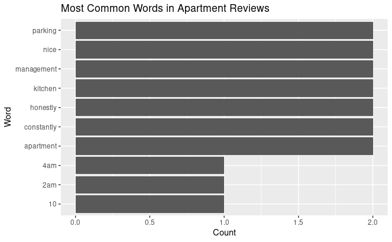

```r
clean_review_words |>
  count(word, sort = TRUE) |>
  slice_head(n = 10) |>
  ggplot(aes(x = reorder(word, n), y = n)) +
  geom_col() +
  coord_flip() +
  labs(
    title = "Most Common Words in Apartment Reviews",
    x = "Word",
    y = "Count"
  )
```

# You Try

Pick one apartment review and answer:

1. Does the cleaned version preserve the meaning of the original review?
2. What information was removed?
3. What information became easier to analyze?

# Limits of Word Counts

Consider these two sentences:

- “dog bites man”
- “man bites dog”

A simple word count treats these as almost identical.

But they clearly mean very different things.

Word order matters.

# Folktales Dataset

Now let’s move to a larger and more complicated text dataset.

```r
folktales <- read_csv("data/folktales.csv", show_col_types = FALSE)
folktales |> head()
```

| ...1 | ATU Code | Author | Country of Origin | Original Title | Source | Story | Story Type | Title | Translated | Year Translated | Year Written |
| --- | --- | --- | --- | --- | --- | --- | --- | --- | --- | --- | --- |
| 17 | 15 | Jacob & Wilhelm Grimm | Germany | Katze und Maus in Gesellschaft | NA | A cat had made the acquaintance of a mouse, and had said so much to her about the great love and friendship that he felt for her, that at last the mouse agreed that they should live and keep house tog… | Stealing the Partner's Butter (ATU 15)\n | Cat and mouse in partnership | Margaret Hunt | 1884 | 1812 |
| 44 | 123 | Jacob & Wilhelm Grimm | Germany | Der Wolf und die sieben jungen Geisslein | NA | There was once an old goat who had seven little ones, and was as fond of them as ever mother was of her children. One day she had to go into the wood to fetch food for them, so she called them all rou… | The Wolf and the Seven Young Kids (ATU 123)\n | The Wolf and the Seven Young Kids | Margaret Hunt | 1884 | 1812 |
| 54 | 516 | Jacob & Wilhelm Grimm | Germany | Der treue Johannes | The Blue Fairy Book (nr. 30) | ONCE upon a time there was an old king who was so ill that he thought to himself, "I am most likely on my death-bed." Then he said, "Send Trusty John to me." Now Trusty John was his favourite servant,… | The Petrified Friend (ATU 516)\n | Trusty John | Andrew Lang | 1889 | 1812 |
| 64 | NA | Jacob & Wilhelm Grimm | Germany | Der gute Handel | NA | There was once a peasant who had driven his cow to the fair, and sold her for seven thalers. On the way home he had to pass a pond, and already from afar he heard the frogs crying, "Aik, aik, aik, aik… | NA | The good bargain | Margaret Hunt | 1884 | 1812 |
| 74 | 151 | Jacob & Wilhelm Grimm | Germany | Der wunderliche Spielmann | NA | There was once a wonderful musician, who went quite alone through a forest and thought of all manner of things, and when nothing was left for him to think about, he said to himself, "Time is beginning… | Music lessons for wild animals (ATU 151)\n | The Wonderful Musician | Translated into English | NA | 1812 |
| 84 | 451 | Jacob & Wilhelm Grimm | Germany | Die zwölf Brüder | NA | There were once on a time a king and a queen who lived happily together and had twelve children, but they were all boys. Then said the King to his wife, "If the thirteenth child which thou art about t… | The Nurse looking for her Brothers, (ATU 451)\n | The twelve brothers | Margaret Hunt | 1884 | 1812 |

```r
folktales |> names()
```

```
 [1] "...1"              "ATU Code"          "Author"            "Country of Origin" "Original Title"
 [6] "Source"            "Story"             "Story Type"        "Title"             "Translated"
[11] "Year Translated"   "Year Written"
```

```r
folktales |>
  count(`Country of Origin`, sort = TRUE) |>
  head(10)
```

| Country of Origin | n |
| --- | --- |
| Greece | 202 |
| Germany | 159 |
| Denmark | 138 |
| Italy | 115 |
| Norway | 99 |
| France | 79 |
| Russia | 58 |
| Spain | 9 |
| Iceland | 6 |
| Spain - Region | 6 |

```r
folktales |>
  select(Title, Author, `Country of Origin`, `Story Type`) |>
  head()
```

| Title | Author | Country of Origin | Story Type |
| --- | --- | --- | --- |
| Cat and mouse in partnership | Jacob & Wilhelm Grimm | Germany | Stealing the Partner's Butter (ATU 15)\n |
| The Wolf and the Seven Young Kids | Jacob & Wilhelm Grimm | Germany | The Wolf and the Seven Young Kids (ATU 123)\n |
| Trusty John | Jacob & Wilhelm Grimm | Germany | The Petrified Friend (ATU 516)\n |
| The good bargain | Jacob & Wilhelm Grimm | Germany | NA |
| The Wonderful Musician | Jacob & Wilhelm Grimm | Germany | Music lessons for wild animals (ATU 151)\n |
| The twelve brothers | Jacob & Wilhelm Grimm | Germany | The Nurse looking for her Brothers, (ATU 451)\n |

# Select a Familiar Story

We’ll focus on Cinderella because:

- it is culturally recognizable
- it contains repeated motifs
- it is long enough for analysis
- it has strong thematic vocabulary

```r
cinderella <- folktales |>
  filter(str_detect(Title, regex("Cinderella", ignore_case = TRUE)))

cinderella |>
  select(Title, `Country of Origin`, Author, `Story Type`)
```

| Title | Country of Origin | Author | Story Type |
| --- | --- | --- | --- |
| Cinderella | Germany | Jacob & Wilhelm Grimm | NA |
| Cinderella; or, The Little Glass Slipper | France | Charles Perrault | Persecuted Heroine (ATU 510A)\n |

The dataset contains multiple versions of Cinderella.

We’ll use the French version because it is closer to the version many readers recognize today and contains familiar story elements.

```r
story <- cinderella$Story[2]

str_sub(story, 1, 1000)
```

```
[1] "Once there was a gentleman who married, for his second wife, the proudest and most haughty woman that was ever seen. She had, by a former husband, two daughters of her own, who were, indeed, exactly like her in all things. He had likewise, by another wife, a young daughter, but of unparalleled …
```

# Word Frequencies

`unnest_tokens()` lowercases and removes punctuation by default.

```r
story_words <- tibble(text = story) |>
  unnest_tokens(word, text) |>
  anti_join(stop_words, by = "word")

story_words |>
  count(word, sort = TRUE) |>
  head(20)
```

| word | n |
| --- | --- |
| cinderella | 25 |
| godmother | 16 |
| ball | 14 |
| sisters | 13 |
| beautiful | 11 |
| fine | 9 |
| king's | 8 |
| son | 8 |
| day | 7 |
| clothes | 6 |

[output cut: 10 more lines]

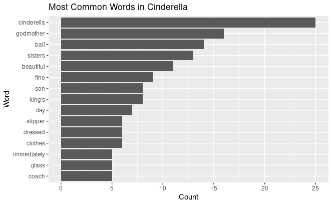

```r
story_words |>
  count(word, sort = TRUE) |>
  slice_head(n = 15) |>
  ggplot(aes(x = reorder(word, n), y = n)) +
  geom_col() +
  coord_flip() +
  labs(
    title = "Most Common Words in Cinderella",
    x = "Word",
    y = "Count"
  )
```

# N-grams

Single words can be useful, but phrases can reveal more structure.

An n-gram is a sequence of words.

Today we will focus on bigrams, or 2-word phrases.

```r
story_bigrams <- tibble(text = story) |>
  unnest_tokens(bigram, text, token = "ngrams", n = 2)

story_bigrams |>
  count(bigram, sort = TRUE) |>
  head(15)
```

| bigram | n |
| --- | --- |
| her godmother | 12 |
| the ball | 12 |
| to the | 11 |
| in the | 10 |
| to her | 10 |
| at the | 9 |
| of the | 9 |
| king's son | 8 |
| she had | 8 |
| they had | 8 |

[output cut: 5 more lines]

# Why N-grams Matter

N-grams preserve some word order information.

For example:

- “glass slipper”
- “evil stepmother”
- “royal ball”

can reveal themes that single words might miss.

# TF-IDF

Word frequency tells us what words are common.

But what words make a story unique?

TF-IDF helps identify words that are:

- common in one document
- uncommon across the whole collection

In plain language:

- TF asks: What words appear often in this story?
- IDF asks: What words are rare across all stories?
- TF-IDF asks: What words help make this story distinctive?

This idea is closely related to how search engines and recommendation systems identify important terms in documents.

# TF-IDF with tidytext

```r
folktale_words <- folktales |>
  mutate(doc_id = row_number()) |>
  select(doc_id, Title, Story) |>
  unnest_tokens(word, Story) |>
  anti_join(stop_words, by = "word") |>
  count(doc_id, Title, word, sort = TRUE)
```

```r
folktale_tfidf <- folktale_words |>
  bind_tf_idf(word, doc_id, n)

folktale_tfidf |>
  arrange(desc(tf_idf)) |>
  head()
```

| doc_id | Title | word | n | tf | idf | tf_idf |
| --- | --- | --- | --- | --- | --- | --- |
| 864 | The Appointment in Samarra | copyright | 3 | 0.3333333 | 6.118097 | 2.0393657 |
| 864 | The Appointment in Samarra | text | 2 | 0.2222222 | 5.424950 | 1.2055444 |
| 106 | Domestic servants | walpe | 11 | 0.1506849 | 6.811244 | 1.0263519 |
| 860 | The Lion, the Panther, the Tazourit, and the Jackal | jackal | 10 | 0.1612903 | 6.118097 | 0.9867899 |
| 603 | The Fox and the Leopard | leopard | 2 | 0.1333333 | 6.811244 | 0.9081659 |
| 350 | One's Own Children Are Always Prettiest | snipe | 5 | 0.1388889 | 6.118097 | 0.8497357 |

# Most Important Words in Cinderella

```r
cinderella_doc_id <- cinderella |>
  mutate(original_row = as.integer(rownames(cinderella))) |>
  slice(2) |>
  pull(original_row)

# Since folktales were read in as a tibble, use the original row number from folktales
cinderella_doc_id <- which(folktales$Title == cinderella$Title[2] & folktales$Story == cinderella$Story[2])[1]
```

```r
cinderella_tfidf <- folktale_tfidf |>
  filter(doc_id == cinderella_doc_id) |>
  arrange(desc(tf_idf)) |>
  slice_head(n = 20)

cinderella_tfidf
```

| doc_id | Title | word | n | tf | idf | tf_idf |
| --- | --- | --- | --- | --- | --- | --- |
| 428 | Cinderella; or, The Little Glass Slipper | cinderella | 25 | 0.032679739 | 5.712632 | 0.18668732 |
| 428 | Cinderella; or, The Little Glass Slipper | godmother | 16 | 0.020915033 | 5.424950 | 0.11346301 |
| 428 | Cinderella; or, The Little Glass Slipper | ball | 14 | 0.018300654 | 2.940043 | 0.05380472 |
| 428 | Cinderella; or, The Little Glass Slipper | sisters | 13 | 0.016993464 | 2.700371 | 0.04588865 |
| 428 | Cinderella; or, The Little Glass Slipper | slipper | 6 | 0.007843137 | 4.326338 | 0.03393206 |
| 428 | Cinderella; or, The Little Glass Slipper | pumpkin | 4 | 0.005228758 | 5.424950 | 0.02836575 |
| 428 | Cinderella; or, The Little Glass Slipper | cinderwench | 3 | 0.003921569 | 6.811244 | 0.02671076 |
| 428 | Cinderella; or, The Little Glass Slipper | wand | 5 | 0.006535948 | 3.920873 | 0.02562662 |
| 428 | Cinderella; or, The Little Glass Slipper | coach | 5 | 0.006535948 | 3.314737 | 0.02166495 |
| 428 | Cinderella; or, The Little Glass Slipper | coachman | 4 | 0.005228758 | 3.978031 | 0.02080016 |

[output cut: 10 more lines]

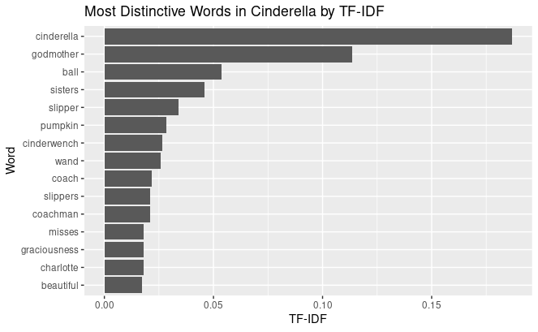

```r
cinderella_tfidf |>
  slice_head(n = 15) |>
  ggplot(aes(x = reorder(word, tf_idf), y = tf_idf)) +
  geom_col() +
  coord_flip() +
  labs(
    title = "Most Distinctive Words in Cinderella by TF-IDF",
    x = "Word",
    y = "TF-IDF"
  )
```

# Comparing Cinderella and Little Red Riding Hood

TF-IDF becomes especially useful when we compare documents.

Let’s compare two familiar stories:

- Cinderella
- Little Red Riding Hood

We expect different stories to have different distinctive words.

```r
little_red <- folktales |>
  filter(str_detect(Title, regex("Little Red", ignore_case = TRUE)))

little_red |>
  select(Title, `Country of Origin`, Author, `Story Type`)
```

| Title | Country of Origin | Author | Story Type |
| --- | --- | --- | --- |
| Little Red Riding Hood | Germany | Jacob & Wilhelm Grimm | Little Red Riding Hood (ATU 333) |
| Little Red Riding Hood | France | Charles Perrault | Little Red Riding Hood (ATU 333)\n |

We’ll compare against the French version of Little Red Riding Hood for the same reason.

```r
little_red_doc_id <- which(folktales$Title == little_red$Title[2] & folktales$Story == little_red$Story[2])[1]
```

```r
little_red_tfidf <- folktale_tfidf |>
  filter(doc_id == little_red_doc_id) |>
  arrange(desc(tf_idf)) |>
  slice_head(n = 20)

little_red_tfidf
```

| doc_id | Title | word | n | tf | idf | tf_idf |
| --- | --- | --- | --- | --- | --- | --- |
| 424 | Little Red Riding Hood | hood | 10 | 0.040650407 | 4.614020 | 0.18756178 |
| 424 | Little Red Riding Hood | grandmother | 12 | 0.048780488 | 3.377257 | 0.16474425 |
| 424 | Little Red Riding Hood | wolf | 14 | 0.056910569 | 2.493756 | 0.14192109 |
| 424 | Little Red Riding Hood | riding | 11 | 0.044715447 | 2.700371 | 0.12074828 |
| 424 | Little Red Riding Hood | bobbin | 4 | 0.016260163 | 5.712632 | 0.09288833 |
| 424 | Little Red Riding Hood | cake | 5 | 0.020325203 | 3.866805 | 0.07859361 |
| 424 | Little Red Riding Hood | red | 11 | 0.044715447 | 1.687280 | 0.07544750 |
| 424 | Little Red Riding Hood | butter | 5 | 0.020325203 | 3.443949 | 0.06999895 |
| 424 | Little Red Riding Hood | tap | 4 | 0.016260163 | 3.978031 | 0.06468343 |
| 424 | Little Red Riding Hood | pot | 5 | 0.020325203 | 2.493756 | 0.05068610 |

[output cut: 10 more lines]

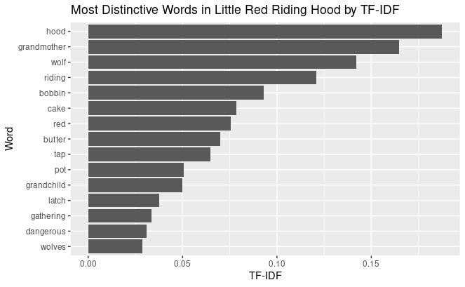

```r
little_red_tfidf |>
  slice_head(n = 15) |>
  ggplot(aes(x = reorder(word, tf_idf), y = tf_idf)) +
  geom_col() +
  coord_flip() +
  labs(
    title = "Most Distinctive Words in Little Red Riding Hood by TF-IDF",
    x = "Word",
    y = "TF-IDF"
  )
```

## Discussion

What do you notice?

- Do the distinctive words match what you know about each story?
- Which words reflect characters?
- Which words reflect objects?
- Which words reflect setting?
- Which words are surprising?

This is where TF-IDF becomes powerful: it helps us identify words that characterize one document relative to a collection.

# You Try

Choose a different folktale and repeat the TF-IDF analysis.

```r
folktales |>
  select(Title, `Country of Origin`) |>
  slice_sample(n = 10)
```

| Title | Country of Origin |
| --- | --- |
| The spirit in the glass bottle | Germany |
| The King of the Sea and Vassilissa the Wise | Russia |
| The Bird of Truth | Spain |
| Going a-travelling | Germany |
| The Horse and Groom | Greece |
| The Wolf and the Seven Young Kids | Germany |
| The Sheep, the Stag, and the Wolf | Italy |
| The Lion in a Farmyard | Greece |
| The tinder-box | Denmark |
| Bushy Bride | Norway |

```r
title_fragment <- "Wolf"

selected_story <- folktales |>
  filter(str_detect(Title, regex(title_fragment, ignore_case = TRUE)))

selected_story |>
  select(Title, `Country of Origin`, Author) |>
  head()
```

| Title | Country of Origin | Author |
| --- | --- | --- |
| The Wolf and the Seven Young Kids | Germany | Jacob & Wilhelm Grimm |
| The wolf and the man | Germany | Jacob & Wilhelm Grimm |
| The wolf and the fox | Germany | Jacob & Wilhelm Grimm |
| Gossip wolf and the fox | Germany | Jacob & Wilhelm Grimm |
| The Wolf and the Goat | Russia | Alexander Afanasyev |
| Tsarevich Ivan and Grey Wolf | Russia | Alexander Afanasyev |

```r
if (nrow(selected_story) > 0) {
  selected_doc_id <- which(folktales$Title == selected_story$Title[1] & folktales$Story == selected_story$Story[1])[1]

  folktale_tfidf |>
    filter(doc_id == selected_doc_id) |>
    arrange(desc(tf_idf)) |>
    slice_head(n = 20)
} else {
  message("No stories matched that title fragment.")
}
```

| doc_id | Title | word | n | tf | idf | tf_idf |
| --- | --- | --- | --- | --- | --- | --- |
| 2 | The Wolf and the Seven Young Kids | wolf | 17 | 0.054662379 | 2.493756 | 0.13631465 |
| 2 | The Wolf and the Seven Young Kids | kids | 8 | 0.025723473 | 4.865334 | 0.12515329 |
| 2 | The Wolf and the Seven Young Kids | paws | 6 | 0.019292605 | 3.815512 | 0.07361117 |
| 2 | The Wolf and the Seven Young Kids | mother | 16 | 0.051446945 | 1.162270 | 0.05979525 |
| 2 | The Wolf and the Seven Young Kids | miller | 4 | 0.012861736 | 3.815512 | 0.04907411 |
| 2 | The Wolf and the Seven Young Kids | baker | 3 | 0.009646302 | 5.019485 | 0.04841947 |
| 2 | The Wolf and the Seven Young Kids | hoarse | 3 | 0.009646302 | 4.731803 | 0.04564440 |
| 2 | The Wolf and the Seven Young Kids | children | 7 | 0.022508039 | 1.569497 | 0.03532631 |
| 2 | The Wolf and the Seven Young Kids | dear | 8 | 0.025723473 | 1.364507 | 0.03509986 |
| 2 | The Wolf and the Seven Young Kids | door | 9 | 0.028938907 | 1.169337 | 0.03383934 |

[output cut: 10 more lines]

# Simple Sentiment Analysis

Sentiment analysis attempts to estimate whether text is:

- positive
- negative
- neutral

Sentiment analysis is useful, but it is also imperfect. It can struggle with sarcasm, context, older language, and cultural nuance.

In R, one simple beginner-friendly approach is to use a sentiment lexicon.

```r
bing_sentiments <- get_sentiments("bing")

review_sentiment <- reviews |>
  mutate(review_id = row_number()) |>
  unnest_tokens(word, Review) |>
  inner_join(bing_sentiments, by = "word") |>
  count(Apartment, Stars, sentiment) |>
  pivot_wider(names_from = sentiment, values_from = n, values_fill = 0) |>
  mutate(sentiment_score = positive - negative)

review_sentiment
```

| Apartment | Stars | negative | positive | sentiment_score |
| --- | --- | --- | --- | --- |
| Campus View | 4 | 2 | 3 | 1 |
| Highland House | 1 | 1 | 0 | -1 |
| Hilltop Lofts | 3 | 2 | 3 | 1 |
| Lakeside Apartments | 1 | 1 | 0 | -1 |
| Maple Terrace | 4 | 1 | 5 | 4 |
| Mockingbird Flats | 5 | 0 | 2 | 2 |
| Mustang Station | 2 | 0 | 2 | 2 |
| University Crossing | 2 | 0 | 1 | 1 |

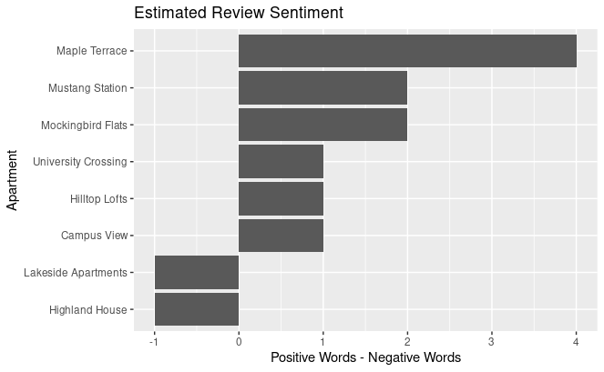

```r
ggplot(review_sentiment, aes(x = reorder(Apartment, sentiment_score), y = sentiment_score)) +
  geom_col() +
  coord_flip() +
  labs(
    title = "Estimated Review Sentiment",
    x = "Apartment",
    y = "Positive Words - Negative Words"
  )
```

Do the sentiment scores match the star ratings?

Why or why not?

# Sentiment in Folktales

```r
folktale_sentiment <- folktales |>
  mutate(doc_id = row_number()) |>
  select(doc_id, Title, `Country of Origin`, Story) |>
  unnest_tokens(word, Story) |>
  inner_join(bing_sentiments, by = "word") |>
  count(doc_id, Title, `Country of Origin`, sentiment) |>
  pivot_wider(names_from = sentiment, values_from = n, values_fill = 0) |>
  mutate(sentiment_score = positive - negative)
```

```r
folktale_sentiment |>
  arrange(desc(sentiment_score)) |>
  select(Title, `Country of Origin`, sentiment_score) |>
  head(10)
```

| Title | Country of Origin | sentiment_score |
| --- | --- | --- |
| The little mermaid | Denmark | 189 |
| The White Cat | France | 144 |
| The Master-Maid | Norway | 130 |
| Under the willow tree | Denmark | 127 |
| The shadow | Denmark | 122 |
| The goloshes of fortune | Denmark | 114 |
| Everything in its proper place | Denmark | 111 |
| The stone of the wise man | Denmark | 105 |
| The gardener and the noble family | Denmark | 105 |
| The snow queen | Denmark | 102 |

```r
folktale_sentiment |>
  arrange(sentiment_score) |>
  select(Title, `Country of Origin`, sentiment_score) |>
  head(10)
```

| Title | Country of Origin | sentiment_score |
| --- | --- | --- |
| The Dog and the Sparrow | Germany | -66 |
| The poor boy in the grave | Germany | -47 |
| Asphurtzela | Georgia | -47 |
| Old Hildebrand | Germany | -42 |
| Ivan the Fool | Russia | -40 |
| Nanny Who Wouldn't Go Home to Supper | Norway | -37 |
| The girl who trod on the loaf | Denmark | -36 |
| The Wise Maid and the Seven Robbers | Russia | -36 |
| Godfather Death | Germany | -33 |
| The bell deep | Denmark | -33 |

Do these rankings seem believable?

What might sentiment analysis miss in older translated folktales?

# Where Might You Use This?

Text analytics appears in many fields:

- News articles
- Interview transcripts
- Social media posts
- Product reviews
- Research papers
- Legislative documents
- Historical archives

The same workflow we used today can often be adapted to these domains.

# Limitations of Text Analysis

Text analysis is powerful, but imperfect.

Some challenges include:

- sarcasm
- ambiguity
- context
- cultural meaning
- humor
- changing language
- translation
- historical language
- missing metadata

Simple methods often lose important meaning.

# AI and Modern Language Models

Many modern AI systems use ideas related to text analysis.

Older approaches:

- counted words
- measured frequencies
- used simple statistics

Modern AI systems:

- model context
- learn relationships between words
- represent language mathematically
- generate new text

Large Language Models are built on these kinds of ideas, but at much larger scales.

# Mini Challenge

Choose one folktale or the apartment review set and investigate it.

Try to:

- clean the text
- count important words
- generate bigrams
- calculate TF-IDF
- visualize something interesting

Then answer:

1. What pattern did you notice?
2. What surprised you?
3. What important meaning might your analysis miss?

# AI Assistant Checkpoint

Try asking an AI assistant:

- “Explain TF-IDF in plain English.”
- “Why do we remove stopwords in text analysis?”
- “What meaning is lost when we use word counts?”
- “How could I improve this text analysis?”
- “Why might sentiment analysis fail on folktales?”